# Capstone Three_V4_18 Jun21

```python
#import required libraries
import pandas as pd
import numpy as np
import matplotlib.pyplot as plt
import seaborn as sns
import math
import warnings
#import spaCy
warnings.filterwarnings('ignore') # Hides warning
warnings.filterwarnings("ignore", category=DeprecationWarning)
warnings.filterwarnings("ignore",category=UserWarning)
sns.set_style("whitegrid") # Plotting style
%matplotlib inline
np.random.seed(7)
```

Business Problem: 1- Which products should be kept, dropped from Amazon’s product roster 2-can we associate positive and negative words/sentiments for each product in Amazon’s Catalog By using Sentiment analysis, can we predict scores for reviews based on certain words

Assumptions:

We’re assuming that sample size of 10K examples are sufficient to represent the entire population of sales/reviews We’re assuming that the information we find in the text reviews of each product will be rich enough to train a sentiment analysis classifier with accuracy (hopefully) > 70%

For Amazon database I downloaded the data from http://jmcauley.ucsd.edu/data/amazon/ for this capstone I am using musical instrument reviews and only the 5 core reviews which is in json format

### Read Data

```python
# read json file
df=pd.read_json(r"C:\Users\zsoltani\Desktop\Zohreh Training and Personal files\Python class\Chapter 24\Musical_Instruments_5.json", lines=True)
```

### Explore Data

```python
#Exploring the data
df.head()
```

[output not shown]

Dataset dictionary: 1 ReviewerID - ID of the reviewer, e.g. A2SUAM1J3GNN3B 2 Asin - ID of the product, e.g. 0000013714 3 Reviewer Name - name of the reviewer 4 Helpful - helpfulness rating of the review, e.g. 2/3 5 Review Text - text of the review 6 Overall - rating of the product 7 Summary - summary of the review 8 Unix Review Time - time of the review (unix time) 9 Review Time - time of the review (raw)

### Explorary Data Analysis and Feature Engineering

```python
print("Summary statistics of numerical features : \n", df.describe())

print("\nTotal number of reviews: ",len(df))

print("\nTotal number of unique products: ", len(list(set(df['asin']))))

print("\nPercentage of reviews with neutral sentiment : {:.2f}%"\
      .format(df[df['overall']==3]["reviewText"].count()/len(df)*100))
print("\nPercentage of reviews with positive sentiment : {:.2f}%"\
      .format(df[df['overall']>3]["reviewText"].count()/len(df)*100))
print("\nPercentage of reviews with negative sentiment : {:.2f}%"\
      .format(df[df['overall']<3]["reviewText"].count()/len(df)*100))
```

```
Summary statistics of numerical features :
             overall  unixReviewTime
count  10261.000000    1.026100e+04
mean       4.488744    1.360606e+09
std        0.894642    3.779735e+07
min        1.000000    1.095466e+09
25%        4.000000    1.343434e+09
50%        5.000000    1.368490e+09
75%        5.000000    1.388966e+09
max        5.000000    1.405987e+09

Total number of reviews:  10261

Total number of unique products:  900

Percentage of reviews with neutral sentiment : 7.52%

Percentage of reviews with positive sentiment : 87.93%

Percentage of reviews with negative sentiment : 4.55%
```

```python
np.unique(df['overall'])
```

```
array([1, 2, 3, 4, 5], dtype=int64)
```

```python
#turning df into dataframe
pd.DataFrame(df)
```

|  | reviewerID | asin | reviewerName | helpful | reviewText | overall | summary | unixReviewTime | reviewTime |
| --- | --- | --- | --- | --- | --- | --- | --- | --- | --- |
| 0 | A2IBPI20UZIR0U | 1384719342 | cassandra tu "Yeah, well, that's just like, u... | [0, 0] | Not much to write about here, but it does exac... | 5 | good | 1393545600 | 02 28, 2014 |
| 1 | A14VAT5EAX3D9S | 1384719342 | Jake | [13, 14] | The product does exactly as it should and is q... | 5 | Jake | 1363392000 | 03 16, 2013 |
| 2 | A195EZSQDW3E21 | 1384719342 | Rick Bennette "Rick Bennette" | [1, 1] | The primary job of this device is to block the... | 5 | It Does The Job Well | 1377648000 | 08 28, 2013 |
| 3 | A2C00NNG1ZQQG2 | 1384719342 | RustyBill "Sunday Rocker" | [0, 0] | Nice windscreen protects my MXL mic and preven... | 5 | GOOD WINDSCREEN FOR THE MONEY | 1392336000 | 02 14, 2014 |
| 4 | A94QU4C90B1AX | 1384719342 | SEAN MASLANKA | [0, 0] | This pop filter is great. It looks and perform... | 5 | No more pops when I record my vocals. | 1392940800 | 02 21, 2014 |
| ... | ... | ... | ... | ... | ... | ... | ... | ... | ... |
| 10256 | A14B2YH83ZXMPP | B00JBIVXGC | Lonnie M. Adams | [0, 0] | Great, just as expected. Thank to all. | 5 | Five Stars | 1405814400 | 07 20, 2014 |
| 10257 | A1RPTVW5VEOSI | B00JBIVXGC | Michael J. Edelman | [0, 0] | I've been thinking about trying the Nanoweb st... | 5 | Long life, and for some players, a good econom... | 1404259200 | 07 2, 2014 |
| 10258 | AWCJ12KBO5VII | B00JBIVXGC | Michael L. Knapp | [0, 0] | I have tried coated strings in the past ( incl... | 4 | Good for coated. | 1405987200 | 07 22, 2014 |
| 10259 | A2Z7S8B5U4PAKJ | B00JBIVXGC | Rick Langdon "Scriptor" | [0, 0] | Well, MADE by Elixir and DEVELOPED with Taylor... | 4 | Taylor Made | 1404172800 | 07 1, 2014 |
| 10260 | A2WA8TDCTGUADI | B00JBIVXGC | TheTerrorBeyond | [0, 0] | These strings are really quite good, but I wou... | 4 | These strings are really quite good, but I wou... | 1405468800 | 07 16, 2014 |

10261 rows × 9 columns

```python
df.dtypes
```

```
reviewerID        object
asin              object
reviewerName      object
helpful           object
reviewText        object
overall            int64
summary           object
unixReviewTime     int64
reviewTime        object
dtype: object
```

##### DISTRIBUTION OF OVERALL RATING FOR 'Musical Instruments' CATEGORY REVIEWS ON AMAZON¶¶

```python
Overall_Rating=df.groupby(['overall'])['reviewerID'].count().reset_index()
Overall_Rating=Overall_Rating.rename(columns={'reviewerID':'Number_of_Reviews'})
Overall_Rating
```

[output not shown]

Majority of examples were rated highly (looking at rating distribution). There is twice amount of 5 star ratings than the others ratings combined.

###### NUMBER OF REVIEWS OVER THE YEARS & MONTHS

```python
df['reviewTime']= pd.to_datetime(df['reviewTime'])
```

```python
df['Month']=df['reviewTime'].dt.month
```

```python
df['Year']=df['reviewTime'].dt.year
```

```python
Yearly_Avg_Rating=df.groupby(['Year'])['overall'].mean().reset_index()
Yearly_Avg_Rating
```

|  | Year | overall |
| --- | --- | --- |
| 0 | 2004 | 4.857143 |
| 1 | 2005 | 4.750000 |
| 2 | 2006 | 4.200000 |
| 3 | 2007 | 4.636364 |
| 4 | 2008 | 4.396825 |
| 5 | 2009 | 4.500000 |
| 6 | 2010 | 4.491429 |
| 7 | 2011 | 4.487587 |
| 8 | 2012 | 4.514979 |
| 9 | 2013 | 4.491985 |
| 10 | 2014 | 4.465099 |

```python
Yearly_Avg_Rating['Moving_Average']=Yearly_Avg_Rating['overall'].rolling(window=3).mean()
```

```python
Yearly_Avg_Rating
```

|  | Year | overall | Moving_Average |
| --- | --- | --- | --- |
| 0 | 2004 | 4.857143 | NaN |
| 1 | 2005 | 4.750000 | NaN |
| 2 | 2006 | 4.200000 | 4.602381 |
| 3 | 2007 | 4.636364 | 4.528788 |
| 4 | 2008 | 4.396825 | 4.411063 |
| 5 | 2009 | 4.500000 | 4.511063 |
| 6 | 2010 | 4.491429 | 4.462751 |
| 7 | 2011 | 4.487587 | 4.493005 |
| 8 | 2012 | 4.514979 | 4.497998 |
| 9 | 2013 | 4.491985 | 4.498184 |
| 10 | 2014 | 4.465099 | 4.490688 |

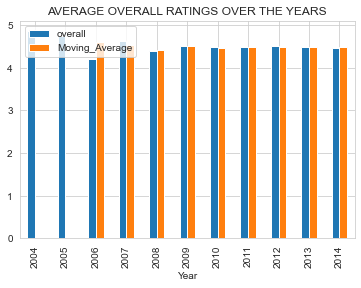

```python
Yearly_Avg_Rating.plot(x="Year",y=["overall","Moving_Average"],kind="bar",title="AVERAGE OVERALL RATINGS OVER THE YEARS")
plt.show()
```

```python
Yearly=df.groupby(['Year'])['reviewerID'].count().reset_index()
```

```python
Yearly=Yearly.rename(columns={'reviewerID': 'Number_Of_Reviews'})
```

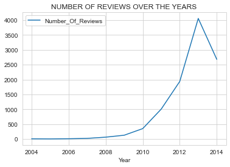

```python
Yearly.plot(x="Year",y="Number_Of_Reviews",kind="line",title="NUMBER OF REVIEWS OVER THE YEARS")
plt.show()
```

```python
Yearly
```

|  | Year | Number_Of_Reviews |
| --- | --- | --- |
| 0 | 2004 | 7 |
| 1 | 2005 | 4 |
| 2 | 2006 | 10 |
| 3 | 2007 | 22 |
| 4 | 2008 | 63 |
| 5 | 2009 | 128 |
| 6 | 2010 | 350 |
| 7 | 2011 | 1007 |
| 8 | 2012 | 1936 |
| 9 | 2013 | 4055 |
| 10 | 2014 | 2679 |

```python
Monthly=df.groupby(['Month'])['reviewerID'].count().reset_index()
```

```python
import calendar
```

```python
# Replacing digits of 'Month' column in 'Monthly' dataframe with words using 'Calendar' library
Monthly['Month'] = Monthly['Month'].apply(lambda x: calendar.month_name[x])
Monthly=Monthly.rename(columns={'reviewerID':'Number_of_Reviews'})
```

```python
Monthly.head()
```

|  | Month | Number_of_Reviews |
| --- | --- | --- |
| 0 | January | 1266 |
| 1 | February | 1063 |
| 2 | March | 1043 |
| 3 | April | 922 |
| 4 | May | 851 |

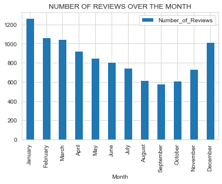

```python
Monthly.plot(x="Month",y="Number_of_Reviews",kind="bar",title="NUMBER OF REVIEWS OVER THE MONTH")
plt.show()
```